# Multidecadal changes in fish growth rates estimated from tagging data: A case study from the Eastern Baltic cod (Gadus morhua, Gadidae) - Mion - 2021 - Fish and Fisheries - Wiley Online Library

[SLU Library](http://www.slu.se/en/library/)

[Fish and Fisheries](https://onlinelibrary.wiley.com/journal/14672979)

[Volume 22, Issue 2](https://onlinelibrary.wiley.com/toc/14672979/2021/22/2) p. 413-427

[figure not shown]

ORIGINAL ARTICLE

Full Access

# Multidecadal changes in fish growth rates estimated from tagging data: A case study from the Eastern Baltic cod (*Gadus morhua, Gadidae*)

[Monica Mion](https://onlinelibrary.wiley.com/action/doSearch?ContribAuthorStored=Mion%2C+Monica)

[Stefanie Haase](https://onlinelibrary.wiley.com/action/doSearch?ContribAuthorStored=Haase%2C+Stefanie)

[Jakob Hemmer‐Hansen](https://onlinelibrary.wiley.com/action/doSearch?ContribAuthorStored=Hemmer-Hansen%2C+Jakob)

[Annelie Hilvarsson](https://onlinelibrary.wiley.com/action/doSearch?ContribAuthorStored=Hilvarsson%2C+Annelie)

[Karin Hüssy](https://onlinelibrary.wiley.com/action/doSearch?ContribAuthorStored=H%C3%BCssy%2C+Karin)

[Maria Krüger‐Johnsen](https://onlinelibrary.wiley.com/action/doSearch?ContribAuthorStored=Kr%C3%BCger-Johnsen%2C+Maria)

[Uwe Krumme](https://onlinelibrary.wiley.com/action/doSearch?ContribAuthorStored=Krumme%2C+Uwe)

[Kate McQueen](https://onlinelibrary.wiley.com/action/doSearch?ContribAuthorStored=McQueen%2C+Kate)

[Maris Plikshs](https://onlinelibrary.wiley.com/action/doSearch?ContribAuthorStored=Plikshs%2C+Maris)

… See all authors

First published: 22 December 2020

https://doi.org/10.1111/faf.12527

## Abstract

Long time series of reliable individual growth estimates are crucial for understanding the status of a fish stock and deciding upon appropriate management. Tagging data provide valuable information about fish growth, and are especially useful when age‐based growth estimates and stock assessments are compromised by age‐determination uncertainties. However, in the literature there is a lack of studies assessing possible changes in growth over time using tagging data. Here, data from tagging experiments performed in the Baltic Sea between 1971 and 2019 were added to those previously analysed for 1955–1970 to build the most extensive tagging dataset available for Eastern Baltic cod (*Gadus morhua, Gadidae*), a threatened stock with severe age‐determination problems. Two length‐based methods, the GROTAG model (based on the von Bertalanffy growth function) and a Generalized Additive Model, were used to assess for the first time the potential long‐term changes in cod growth using age‐independent data. Both methods showed strong changes in growth with an increase until the end of the 1980s (8.6–10.6 cm/year for a 40 cm cod depending on the model) followed by a sharp decline. This study also revealed that the current growth of cod is the lowest observed in the past 7 decades (4.3–5.1 cm/year for a 40 cm cod depending on the model), indicating very low productivity. This study provides the first example of the use of tagging data to estimate multidecadal changes in growth rates in wild fish. This methodology can also be applied to other species, especially in those cases where severe age‐determination problems exist.

| 1 INTRODUCTION | 414 |
| --- | --- |
| 2 MATERIAL AND METHODS | 415 |
| 2.1 Data overview | 415 |
| 2.1.1 Historical data | 416 |
| 2.1.2 CODYSSEY project | 416 |
| 2.1.3 TABACOD project | 416 |
| 2.2 Data preparation | 417 |
| 2.3 Growth analyses | 417 |
| 2.3.1 GROTAG model | 419 |
| 2.4 Generalized Additive Model | 420 |
| 3 RESULTS | 421 |
| 3.1 GROTAG model | 421 |
| 3.2 Generalized Additive Model | 421 |
| 4 DISCUSSION | 421 |
| 5 CONCLUSIONS | 424 |
| ACKNOWLEDGEMENTS | 424 |
| DATA AVAILABILITY STATEMENT | 424 |
| REFERENCES | 424 |

## 1 INTRODUCTION

Growth describes how body size changes with time, and variation in growth can have substantial consequences for survival, age at sexual maturity, reproductive success and movements, modulating the response of populations to environmental changes and anthropogenic pressures including fisheries (Dortel et al., 2014; Peters, 1983). Therefore, long time series of reliable growth estimates are crucial for evaluating the present and past status of a fish stock and deciding upon appropriate fisheries management actions under ecosystem changes (Aires‐da‐Silva et al., 2015; Dortel et al., 2014; Kell & Bromley, 2004; Vincenzi et al., 2014).

For temperate teleost fish species, growth estimates and stock assessment generally rely on age determination through the interpretation of otolith annual increments. However, numerous examples of severe age‐reading uncertainties and inconsistencies causing highly inaccurate estimates of population dynamics exist (Campana, 2001; Kastelle et al., 2017), resulting in extreme cases in the abandonment of age‐based analytical stock assessments (e.g. de Pontual et al., 2006; ICES, 2014a; 2015). By contrast, tagging methods provide valid data for length‐based growth modelling for many fish families, including gadoids (e.g. cod; McQueen et al., 2019; Shackell et al., 1997; Tallack, 2009). Those data have also been integrated into stock assessment as in the case of some tuna species (e.g. Ailloud et al., 2014; Aires‐da‐Silva et al., 2015; Dortel et al., 2014; Hearn & Polacheck, 2003; Restrepo et al., 2010) and hake (de Pontual et al., 2013). However, to the best of our knowledge, tagging data have never previously been used for assessing possible changes in growth over long time periods.

The Baltic Sea is one of the largest brackish water areas in the world, where severe changes in biotic and environmental conditions have occurred in the past hundred years (Reusch et al., 2018). Historically, cod (*Gadus morhua, Gadidae*) has been one of the most important commercial species in the Baltic Sea (Bagge et al., 1994; ICES, 2014b) and, as a major piscivorous fish, has important structuring roles in the ecosystem (Casini et al., 2009). During the past hundred years, the Eastern Baltic cod (EBC) stock size has changed considerably, with a peak in the early 1980s when the stock yielded the third‐largest landings of all cod stocks in the North Atlantic (ca. 200.000 t). Since then, the stock has been in decline and is currently one of the most severely threatened fish stocks in Europe (ICES, 2020a). From 2019, the advice for EBC is for a closure of the fisheries (ICES, 2020b).

Concurrent with the decline in stock size, a number of changes have been observed in the EBC stock, which include reduced body condition, maturation at a smaller size, increased parasite infestation and thiamine deficiency (Eero et al., 2015; Engelhardt et al., 2020; Horbowy et al., 2016). Additionally, a decline in relative abundance of larger individuals (i.e. >35–40 cm) and a drop in maximum length have occurred (Eero et al., 2015; ICES, 2019a; Orio et al., 2017). However, due to the lack of reliable age determination for this stock (Hüssy et al., 2016; ICES, 2014a, 2014b), it is unclear whether the change in size structure of the stock is the result of reduced growth or increased mortality of older individuals, or both.

The existence of ageing problems in the EBC stock has been known since the implementation of an analytical stock assessment in the beginning of the 1970s (Hüssy et al., 2016; ICES, 1972). To overcome this problem, stock assessment models that can handle length‐based data are currently used (e.g. Stock Synthesis; ICES, 2019b). However, such approaches still require information on individual growth, especially if growth is changing. Accurate information on temporal patterns in growth is therefore required (Eero et al., 2015; ICES, 2018).

Previous studies based on weight‐at‐age data from commercial landings suggested changes in growth for EBC with an increase between 1980 and the early 1990s and a subsequent decline (Brander, 2007; ICES, 2013). However, the severe age‐determination uncertainties and inconsistences (Hüssy et al., 2016) have put into question the trend observed. In addition, caution is needed when using weight‐at‐age data (especially those from commercial landings) as proxy for growth since they are also affected by size‐selective fishing mortality and high‐grading practices, besides changes in individual body condition. The study by Hüssy et al. (2018), based on otolith daily increment and year classes identification from length‐frequency data, suggested a decline in growth rates also of young cod from the early 2000s, but the potential magnitude of change in growth of older cod was not assessed since the methodologies used are not suitable for older individuals (Hüssy et al., 2018).

Extensive tagging experiments on Baltic cod have been performed by the countries bordering the Baltic Sea from the late 1950s to the 1980s (Bagge et al., 1994) and have continued more sporadically thereafter. These historical tagging data were mainly used to analyse cod movements over the Baltic seascape (reviewed in Aro, 1989 and Aro, 2002), but they have been underutilized for growth analyses. Although some estimates of growth based on the historical tagging data exist, they are mainly limited to single national surveys and cover limited periods (Draganik & Netzel, 1966; Mion et al., 2020; Sjöblom et al., 1980).

In this study, we extended the historical database used in Mion et al. (2020), which is based on tagging data collected during 1955–1970, by collating and digitizing the existing archived data from the countries that have performed tagging experiments in the Baltic Sea between the 1970s and the 1990s. In addition, data from international tagging experiments carried out in the southern Baltic Sea in the 2000s and in recent years (2016–2019) have also been integrated with the collated historical data. With this extensive dataset, which represents the longest available time series of tagging data for the EBC over the whole area of its distribution, we reconstructed for the first time growth pattern in cod over the past 7 decades. This study is an example of the potential of tagging data for assessing time series of growth, which is especially important for those stocks and species suffering from age estimation problems.

## 2 MATERIAL AND METHODS

### 2.1 Data overview

For this study, data from (a) historical tagging experiments carried out in the Baltic Sea, and the more recent projects (b) CODYSSEY (Cod spatial dynamics and vertical movements in European waters and implications for fishery management) and (c) TABACOD (Tagging Baltic Cod) were combined in a common database.

#### 2.1.1 Historical data

The historical tagging database of Baltic cod compiled in Mion et al. (2020) covering the period 1955–1970 was extended by digitizing and collating additional historical data from tagging experiments between the 1970s and the 1990s by Sweden, Poland, Latvia, Finland, Denmark and Germany within ICES Subdivisions (SDs) 23–32 (Figure 1). Data for a total of 10,143 recaptured cod were available, covering a release period between 1955 and 1993 (Table 1).

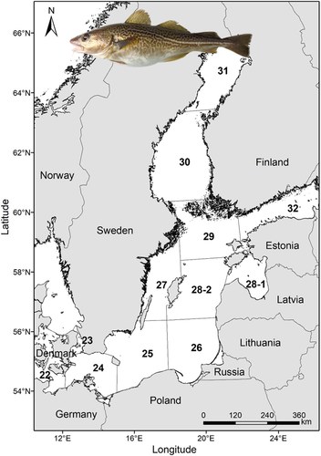

**Figure 1**

Open in figure viewer[PowerPoint](https://onlinelibrary.wiley.com/action/downloadFigures?id=faf12527-fig-0001&doi=10.1111%2Ffaf.12527)

Map of the Baltic Sea, divided into ICES subdivisions. On top, a picture of a Baltic cod (*Gadus morhua, Gadidae*; © Christina Waitkus). Figure appears in colour in the online version only.

Table 1. Overview of the available tagging data (number of released and recaptured cod) from the historical experiments and the projects CODYSSEY and TABACOD, by release country and release period.

| Project | Release country | Release period | Number of released cod | Number of recaptured cod | Return rate (%) |
| --- | --- | --- | --- | --- | --- |
| Historical data | Sweden | 1955–1993 | 43,343 | 4,981 | 11.5 |
|  | Poland | 1957–1970 | 15,183 | 2,299 | 15.1 |
|  | Denmark | 1957–1984 | 9,824 | 1,348 | 13.7 |
|  | Latvia | 1958–1977 | 10,552 | 762 | 7.2 |
|  | Germany | 1959–1974 | 869 | 132 | 15.2 |
|  | Finland | 1974–1984 | 6,425<sup>a</sup> | 621 | 9.7<sup>b</sup> |
|  | All | 1955–1993 | 86,196<sup>a</sup> | 10,143 | 11.8<sup>b</sup> |
| CODYSSEY | Denmark | 2003–2006 | 446 | 234 | 52.5 |
| TABACOD | Sweden | 2016–2018 | 6,386 | 62 | 1.0 |
|  | Poland | 2016–2018 | 5,409 | 60 | 1.1 |
|  | Denmark | 2016–2018 | 5,184 | 87 | 1.7 |
|  | Germany | 2016–2019 | 8,373 | 166 | 2.0 |
|  | All | 2016–2019 | 25,352 | 375 | 1.5 |

- <sup>a</sup> Information about the total number of cod released by Finland was not available for the period 1979–1984.
- <sup>b</sup> The return rate includes Finnish releases only for the period 1974–1978 because the number of releases for the period 1979–1984 was not available.

The records in the compiled database of all recaptured cod included information on release and recapture location, date and total length, as well as occasional information on total weight, sex and maturity stage that were not considered in this analysis. In total, there were 8,622 records with clear information on both release and recapture dates, geographical position at least at the ICES SD resolution and length measurements. The historical tagging activities were performed year‐round, except for the warmest months in the 3<sup>rd</sup> quarter which were less sampled, when the thermocline is more pronounced and less tolerated by cod at release (Otterlind, 1984; Figure 2a).

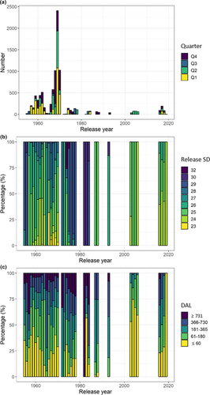

**Figure 2**

Open in figure viewer[PowerPoint](https://onlinelibrary.wiley.com/action/downloadFigures?id=faf12527-fig-0002&doi=10.1111%2Ffaf.12527)

Overview of recaptured Baltic cod (fish releases for which there was a corresponding recapture) by year of release and (a) quarter of release, (b) release subdivision (SD) in percentage and (c) days at liberty (DAL) in percentage (n = 8,622 for the historical data; n = 234 for CODYSSEY; n = 358 for TABACOD). Figure appears in colour in the online version only

Information about the historical tagging procedures was available from literature for all tagging experiments (Swedish experiments: Otterlind, 1969; Otterlind, 1984; Danish tagging experiments: Bagge, 1969; Bagge, 1970; Polish tagging experiments: Netzel, 1976; Latvian tagging experiments: Kondratovich, 1980; German tagging experiments: Berner, 1962; Berner, 1967; Bingel, 1981; Finnish tagging experiments: Sjöblom et al., 1980). In the Swedish, Danish, Polish, Latvian and German tagging experiments cod were fished with bottom trawl hauls from chartered fishing cutters or research vessels. To enhance survival, fish were placed in a flow‐through tank with surface seawater before the tagging procedures and only fish not damaged during capture were tagged. After tagging cod were immediately released at the surface at the same location where they were caught, with the exception of two tagging experiments in 1968 where the fish were released at the bottom using a release cage (Otterlind, 1969, 1984). All the tagged cod, which were unable to swim, were retrieved and removed from the tagging list. In the Finnish experiments, cod were mainly caught with gillnets and longline. In the Gulf of Finland (SD 32) cod were held some days in tanks before tagging and subsequent release, while in the Åland Sea (SD 29) cod were tagged and released immediately after capture (Sjöblom et al., 1980).

Overall, the main release areas for the recaptured fish were within ICES SDs 25–32 (Figure 2b). The individual measurements (i.e. total length and total weight) and other information (e.g. location) of the recaptured fish were reported mainly by the fishers through letters addressed to the research institutes involved in the tagging project (Figure 3). The length of recaptured cod ranged from 140 to 1,100 mm (median: 440 mm) and the time between release and recapture (days at liberty, DAL) ranged between 0 and 3,928 days (median: 128 days; Figure 2c). The return rate (i.e. the % of tagged cod that were recaptured and reported to the research institutes) for the historical tagging experiments was on average 11.8% (Table 1). Around 75% of the recaptures had information on the tag type used. Most of the recaptured tags were Lea´s hydrostatic tags (54%), followed by T‐bars (15%), and Carlin tags (5%), while less than 1% of fish were tagged with Peterson discs (for description of the tags used in the historical Baltic cod tagging experiments see Mion et al., 2020). Around 59% of the recaptures contained information about the recapture gear (43% active gears, i.e. trawls; 16% passive gear, i.e. gillnets, longlines, traps and pots).

[figure not shown]

**Figure 3**

Open in figure viewer[PowerPoint](https://onlinelibrary.wiley.com/action/downloadFigures?id=faf12527-fig-0003&doi=10.1111%2Ffaf.12527)

(a) Example of an historical Swedish recapture letter sent by a fisherman in 1971 (sensitive data about the fisherman has been redacted). The recapture letter reported the species (Fiskart), tag number (Nr), location of the recapture (Fångstplats), date of recapture (Datum), depth (djup; it was not reported in this example), recapture gear (Redskap), total length (Fiskens totala längd) and total/gutted weight (Vikt orensad/rensad). (b) Example of an historical German recapture letter sent by the German research institute in Rostock to the Swedish research institute in Lysekil in 1964 (sensitive data about the fisherman has been redacted). The recapture letter reported the tag number (i.e. C 176), location of the recapture (i.e. Southeast Utklippan), date of recapture (i.e. 15/01/64), length (Fiskens totala längd) and gutted weight (Gewicht geöffnet). Figure appears in colour in the online version only.

The aim of the TABACOD project was to collect data on growth rates and otolith formation of EBC. A total of 25,352 cod were tagged by Denmark, Germany, Sweden and Poland in the current main distribution area of the EBC stock (SDs 24–26) between 2016 and 2019. Fish were mainly caught by bottom trawling from commercial and research vessels, using mainly short hauls of 5–30 min’ duration at 12–74 m depth. 10% of the cod were captured using fish traps, pound nets and angling. In order to enhance survival and to select the fish in good health (i.e. not showing injuries or barotrauma caused by trawling), fish were placed in a tank supplied with flowing seawater prior to tagging procedures.

Fish in good health were tagged externally using numbered T‐bar anchor tags inserted across the pterygiophores below the first dorsal fin and internally through intraperitoneal injection of tetracycline‐hydrochloride (following Stötera et al., 2018). In addition, a subset (5%) of cod was tagged with surgically implanted DSTs and marked externally with two T‐bar anchor tags.

After individual measurements (total length to the lowest millimetre and total weight to the nearest gram) and tagging procedures, fish were usually retained in tanks supplied with flowing seawater for up to 1 hour, to recover from the tagging procedure before being released at the location of capture. Fish caught with a trawl were mainly released using a cage at approximately the same depth of capture both for acclimatization and for avoiding predation from seagulls. Fish caught by other gear types were released at the surface. The length range of cod tagged for this study was 148 to 652 mm (median: 355 mm).

By November 2019, 375 recaptured cod were reported (Table 1; i.e. 1.5% return rate). Information about the recapture gears was available for 94% of the recaptures; 66% active (i.e. commercial trawls) and 34% passive (i.e. commercial gillnets, longlines, traps and pots). In addition, 8 cod were recaptured by recreational fishers. For 358 recaptures, length and weight measurements were recorded. The length of recaptured cod ranged from 253 to 617 mm (median: 422 mm) and the DAL ranged between 0 and 876 days (median: 174 days).

### 2.2 Data preparation

Before undertaking growth analyses, some data filters were applied in a stepwise approach following Mion et al. (2020; Figure S1). In the Baltic, two cod stocks occur, that is EBC and Western Baltic cod (WBC), located in ICES SDs 24–32 and 22–24, respectively (Figure 1), with a main mixing area in SD 24 (Hüssy et al., 2016). In order to identify the recaptured individuals which most likely belonged to the EBC stock, different methods were applied: (a) for the historical and CODYSSEY data, no information on the stock of origin was available and thus a regional assignment has been applied. Following Mion et al. (2020), to reduce the inclusion of WBC individuals in the growth analyses, only fish which were both released and recaptured within the SDs 25–32 were included, excluding the main mixing area of the stocks (i.e. SD 24). This procedure is supported by the lower exchange of the WBC towards the eastern area (Berner, 1967; Hemmer‐Hansen et al., 2019; Hüssy et al., 2016). (b) For the TABACOD data, for 70% of the recaptures the stock of origin was assigned genetically, using SNP genotyping of tissue samples from jaw, muscle or gill stored in ethanol (95%), following the method described in Hemmer‐Hansen et al. (2019). Where genetic analysis was not possible, for 30% of the recaptures, otolith shape analysis was applied using a genetically validated baseline of stock‐specific shapes derived from Schade et al. (2019). These analyses revealed that 285 fish recaptured in the TABACOD project belonged to the EBC stock. Another 44 fish were excluded from the analyses due to lack of genetic or otolith samples. In addition, a sensitivity analysis on the growth estimates (see below) was done for the TABACOD data assigning the stock of origin through the same regional assignment method used for the historical and CODYSSEY data.

The measurements of the recaptured cod during the historical period were assumed to be taken from fresh fish since no detailed information was available and most of the recaptures were reported directly by fishers or anglers. For the recaptures of CODYSSEY and TABACOD, when fish were stored in a freezer and the measurements taken after thawing, a shrinkage conversion factor, developed for Baltic cod was applied (McQueen, et al., 2019).

Only fish with DAL ≥ 60 were included in the analyses to ensure enough time for measurable growth to occur. To exclude fish with unrealistically high growth rates, likely caused by measurement errors, all fish in the database with predicted annual growth > 25 cm/year were excluded from further analyses (Mion et al., 2020). To remove extreme negative growth values (i.e. recapture length << release length), the same percentile of fish growing above the cut‐off of 25 cm/year (i.e. 3%) was used to remove the data from the left tail of the growth distribution (i.e. negative growth; Figure S2). After filtering using these criteria, 4,407 cod qualified for growth estimation for the historical data, 34 for CODYSSEY and 219 for TABACOD.

### 2.3 Growth analyses

To analyse growth, two length‐based models were used: (a) the maximum likelihood GROTAG model (Francis, 1988a; applied for EBC in Mion et al., 2020), which is based on the von Bertalanffy growth function (VBGF), and (b) a generalized additive model (GAM), which does not assume any a priori growth trajectory.

#### 2.3.1 GROTAG model

Growth parameters were estimated for four periods which were selected considering the data availability, and which also corresponded to the main changes in the EBC stock size based on Eero et al. (2007): (a) 1971–1980 (increase in stock size), (b) 1980–1990 (peak in stock size and subsequent decline), (c) 2003–2006 (stock size at the lowest level observed in the time series since the 1950s) and (d) 2016–2019 (stock in poorest body condition level detected so far). The earlier periods 1955–1964 and 1965–1970 were analysed by Mion et al. (2020) using the same data filters and the same method as in the present study. The length‐frequency distribution for length at release (*L<sub>1</sub>*) and length at recapture (*L<sub>2</sub>*) for the different periods are presented in Figure S3.

The VBGF is commonly used to describe individual fish growth, modelling fish length as a function of age. The VBGF parameters are *L<sub>∞</sub>* (i.e. the asymptotic length at which growth rate is theoretically zero), *k* (i.e. the Brody growth coefficient, which determines how fast the fish approaches *L<sub>∞</sub>*) and *t<sub>0</sub>* that is the theoretical age at zero length. To model growth as a function of length at release (*L<sub>1</sub>*) and time between release and recapture, we used a reparametrization of the age‐based VBGF, which is commonly applied to tagging data (Fabens, 1965):

where *∆L* is the change in length between *L<sub>1</sub>* and *L<sub>2</sub>*, and *∆T* is the time between release (*T<sub>1</sub>*) and recapture (*T<sub>2</sub>*) (Francis, 1988a). To standardize the dates, *T<sub>1</sub>* and *T<sub>2</sub>* were measured in fraction of years from the 1<sup>st</sup> of January of the year of the first tagged cod release.

The growth parameters were estimated applying the maximum likelihood GROTAG technique (Francis, 1988a) using the function “grotag” from the R package “fishmethods” (Nelson, 2016) in R v3.5.2 (R Core Team, 2018). The GROTAG model includes the parameters *g<sub>α</sub>* and *g<sub>β</sub>* that are the mean annual growth rates at two release sizes (*α* and *β*, respectively, where *α* < *β*). Parameters *g<sub>α</sub>* and *g<sub>β</sub>* can be used to estimate the conventional parameters *L<sub>∞</sub>* and *k* of the VBGF by the equations (Francis, 1988b):

Reference lengths for *α* and *β* which are well represented by the length distribution of the tagging data should be chosen (Francis, 1988a). In our study, the 5th percentile value of *L<sub>1</sub>* measurements was adopted for α and the 95<sup>th</sup> percentile value of *L<sub>1</sub>* measurements was adopted for *β* (as in Tallack, 2009; see also Mion et al., 2020).

Francis´s model allows the inclusion of additional parameters that can improve model fit, including the following: (a) the standard deviation of the measurement error (*s*), (b) the standard deviation of the growth increment (*nu*), (c) the mean of the measurement error (*m*), (d) the outlier contamination probability (*p*), when *p* > 0.05 caution is required in interpreting the model fit since it indicates a high level of outliers (Francis, 1988a) and (e) the seasonal growth, which includes a proportion that describes when growth is at its maximum in relation to the 1<sup>st</sup> of January (*w*), and the amplitude of seasonal growth (*u*) that ranges from 0 to 1 (with *u* = 0 and *u* = 1 representing no seasonal growth and maximum seasonal growth effect, respectively). The ratio of maximum and minimum instantaneous growth rate is (1 + *u*):(1 − *u*).

The GROTAG model was selected since it incorporates individual variation in growth rate, is suitable for handling large datasets (Tallack, 2009) and has been successfully applied to tagging data to estimate growth rates of cod (McQueen et al., 2019; Mion et al., 2020; Tallack, 2009).

Model selection was done as in Francis (1988a), involving incremental combinations of the parameters (Table 2), with unfitted parameters held at zero. The best model (i.e. final model) was selected through Akaike´s information criterion (AIC; Akaike, 1973), with improved model fit indicated by a ∆AIC value ≤ 6 to select the most parsimonious model (where ∆AIC value is defined as the difference between the AIC values of the model with the lowest AIC and the remaining models with less parameters; Richards, 2005, 2008). The model fit was also visually assessed by plotting the residuals (observed‐expected growth) versus relative age at the time of tagging and time at liberty (Ailloud et al., 2014). Residual deviation was expected to decrease as relative age increases, because the likelihood function assumes an allometric relationship between individual growth variation and mean growth, and the latter declines with length and thus relative age (Bradley et al., 2017; Francis, 1988a). Relative age is calculated by inverting the VBGF (Ailloud et al., 2014).

Table 2. Parameter combinations estimated by the GROTAG model: five models were applied to the dataset to evaluate optimal model parameterization

| GROTAG model | Estimated parameters |
| --- | --- |
| Model 1 | *g<sub>α</sub>, g<sub>β</sub>, s* |
| Model 2 | *g<sub>α</sub>, g<sub>β</sub>, s, nu* |
| Model 3 | *g<sub>α</sub>, g<sub>β</sub>, s, nu, m* |
| Model 4 | *g<sub>α</sub>, g<sub>β</sub>, s, nu, m, p* |
| Model 5 | *g<sub>α</sub>, g<sub>β</sub>, s, nu, m, p, u, w* |

To estimate the variance of the VBGF parameters, each period´s dataset was bootstrapped 1,000 times following Mion et al. (2020). For each period, an approximate 95% confidence interval for *L<sub>∞</sub>* and *k* was then constructed using the bootstrap variance.

Recaptures released in 1993 (n = 33) and during 2003 and 2006 (CODYSSEY project; n = 34) were excluded from the GROTAG analyses, as for these years only small sample sizes, with only large‐sized cod, were available (Figure S3e).

In order to compare the growth estimates between periods, the parameters *g<sub>α</sub>* and *g<sub>β</sub>* were used to estimate the mean annual growth of cod for the same selected length *γ* for each period using the following equation (Francis, 1988a):

The corresponding 95% confidence intervals were estimated from the standard errors calculated as in Francis (1988a).

### 2.4 Generalized additive model

where *a* is the intercept, *te* is the tensor product smoothing function and *ε* an error term.

An interaction was used between the continuous variables *L<sub>1</sub>* and *DAL* since the shape of the effect of fish size at release (*L<sub>1</sub>*) on *∆L* can be affected by how long the fish has been at sea before being recaptured (DAL). This interaction can change between periods, therefore, the factor *Period* was also put in interactions with (*L<sub>1</sub>**DAL).

In addition, we parametrized a second model replacing the factor *Period* with the continuous variable year at release (*Year<sub>1</sub>*) using the following equation:

In this model, the periods were not set a priori and *∆L* was therefore allowed to change annually.

For both GAM formulations, a gamma distribution with a logarithmic link function was used because it best represented the distribution of *∆L* frequencies according to the skewness–kurtosis plot for continuous data (i.e. lognormal distribution; Figure S4; Cullen & Frey, 1999). The models (Equations 5 and 6) were used to predict the mean annual growth and 95% confidence interval of cod from 25 to 45 cm (by 5 cm steps), for each *Period* and *Year<sub>1</sub>* respectively, using the predict.gam function from the package mgcv (Wood, 2006) in R v3.5.2 (R Core Team, 2018). Due to the low availability of recaptured cod that have been out for a longer time, we excluded all the recaptures with DAL > 1,300 days from the GAM analyses (remaining data n = 4,558). In addition, for larger fish the predicted *∆L* of the individuals with DAL > 1,300 declined, contrary to the expectation that an asymptote should be reached.

## 3 RESULTS

### 3.1 GROTAG model

For the period 1971–1980, model 4 (i.e. including *g<sub>α</sub>, g<sub>β</sub>, s, nu*, *m* and *p*) was selected as the final model (Table S1). For the periods 1981–1990 and 2016–2019, a simpler model (i.e. including *g<sub>α</sub>, g<sub>β</sub>, s, nu*, model 2) was selected according to the AIC values (Tables S2 and S3). The best‐fitting models for the periods selected did not include the seasonality parameters. The distribution of the model residuals for the final model for each period is presented in Figure S5.

During the period 1971–1980, the mean growth rates for a 31 cm (*α*) and 72 cm (*β*) cod were 9.26 cm/year and 4.31 cm/year, respectively (Table S1). The growth variability parameter (*nu*) was estimated as 0.57, indicating that individuals within the population could be expected to grow between 0.43 and 1.57 times the estimated average growth (Table S1). The contamination probability (*p*) was negligible (0.01), indicating that the occurrence of outliers was scarce, and the model did not detect outliers after the data cleaning. The mean measurement error (*m*) was close to zero (0.08 cm) and the standard deviation in measurement error (*s*) was 1.13 cm, which is in accordance with the 1 cm precision of the length measurements recorded in the historical tagging data (Table S1). The VBGF parameter’ estimates derived from the GROTAG function were *L<sub>∞</sub>* = 107.73 cm and *k* = 0.13 (Table S1).

During the period 1981–1990, the mean growth rates for a 26 cm (*α*) and 63 cm (*β*) cod were 11.78 cm/year and 3.43 cm/year, respectively (Table S2). The growth variability parameter (*nu*) was estimated as 0.61, indicating that individuals within the population could be expected to grow between 0.39 and 1.61 times the estimated average growth (Table S2). The standard deviation of measurement error (*s*) was higher than the 1 cm precision of the length measurements recorded in the historical tagging data (i.e. 4.07 cm), probably due to the low number of data available for this period and the fact that in this simpler model, *p* and *m* are not included, therefore the variability is accounted mainly by *s* (Table S2). The VBGF parameter’ estimates derived from the GROTAG function were *L<sub>∞</sub>* = 78.21 cm and *k* = 0.26 (Table S2).

During the period 2016–2019, the mean growth rates for a 28 cm (*α*) and 47 cm (*β*) cod were 6.57 cm/year and 4.18 cm/year respectively (Table S3). The growth variability parameter (*nu*) was estimated as 0.66, indicating that individuals within the population could be expected to grow between 0.34 and 1.66 times the estimated average growth (Table S3). The standard deviation of measurement error (*s*) was 0.69 cm (Table S3). The VBGF parameter estimates derived from the GROTAG function were *L<sub>∞</sub>* = 80.12 cm and *k* = 0.13 (Table S3).

The median bootstrapped estimates of *L<sub>∞</sub>* and *k* for the different periods (Table S4) were in line with the estimates from the original datasets (Tables S1, S2 and S3). The joint bootstrapped estimates of *L<sub>∞</sub>* and *k* for the different periods are shown in Figure S6.

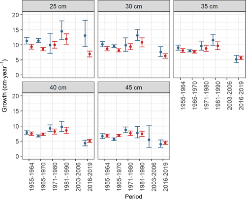

**Figure 4**

Open in figure viewer[PowerPoint](https://onlinelibrary.wiley.com/action/downloadFigures?id=faf12527-fig-0004&doi=10.1111%2Ffaf.12527)

Predicted average annual growth rates (cm/year; dots) and 95% confidence intervals (vertical lines) for 25, 30, 35, 40 and 45 cm cod for different periods calculated from the GROTAG final models (red) and GAM (Equation 5; blue). The predicted average growth rates (cm/year) for the periods 1955–1964 and 1965–1970 analysed with GROTAG are based on Mion et al. (2020). Figure appears in colour in the online version only

### 3.2 Generalized additive model

The GAMs based on selected periods (Equation 5) and year of release (Equation 6) explained 47.2% and 47.7% of the deviance, respectively (see Tables S5 and S6 for the statistics of the models). Visual inspection of the residuals of the models revealed, in some cases, slight departures from the model assumptions, but we considered the overall quality of the residuals to be satisfactory (Figure S7). The predicted average annual growth for the GAM based on selected periods (Equation 5) oscillated during 1955–1980 until it reached a peak in the 1980s. In particular, for smaller cod (i.e. 25 cm) the growth in the 1980s increased by 28% above the growth rates estimated from 1955–1970. For larger cod (i.e. 45 cm) higher growth rates were already apparent in the 1970s (Figure 4) with a 42% increase above 1955–1970. In the latest period, after this peak, growth declined, especially for cod larger than 25 cm (e.g. 54% decline below the peak for a 45 cm cod). For smaller cod (i.e. 25 cm) the decline from the peak in growth was less pronounced (i.e. 10% decline), with wider confidence intervals and recent growth rates similar to 1955–1970.

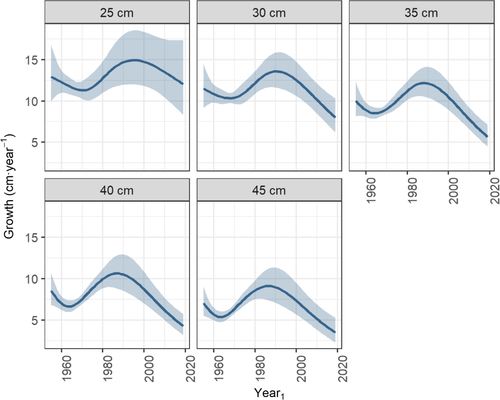

**Figure 5**

Open in figure viewer[PowerPoint](https://onlinelibrary.wiley.com/action/downloadFigures?id=faf12527-fig-0005&doi=10.1111%2Ffaf.12527)

Predicted average growth rates (cm/year) for a 25, 30, 35, 40 and 45 cm cod for different years at release (*Year<sub>1</sub>*) analysed with GAM (Equation 6; blue line). The shaded blue area represents the 95% confidence interval. Figure appears in colour in the online version only

The sensitivity analyses using GAMs based on selected periods (Equation 5) and years of release (Equation 6), revealed that the growth estimates for the 2016–2019 period based on the regional assignment of the stock (n = 97) did not differ from the estimates based on genetics and otolith shape analysis (*n* = 219; Figures S8 and S9). Except for smaller fish (i.e. 25 cm), growth estimates based on regional assignment were smaller than for the ones based on genetics and otolith shape for both the models.

## 4 DISCUSSION

In this study, the longest time series of age‐independent growth estimates based on tagging data has been provided for the first time for the EBC stock. Our analyses show that growth of the EBC has changed over the past 7 decades, with an increase in the 1980s followed by a prolonged decline. This study also demonstrates that EBC growth is currently the lowest ever observed in the last 7 decades, indicating a very low current productivity. According to both the methods used, a cod of 40 cm presently increases on average 4.6 cm in length per year, which is 37% and 52% lower than the growth rate of the same size in the 1960s and 1980s, respectively. Assuming constant condition, the average increase in weight per year for a cod of 40 cm with an average weight of 621 grams is presently 241 grams, which is 41% and 57% lower than the growth rate in weight of the same size fish in the 1960s and 1980s, respectively. This information is an additional indicator of the current distressed status of this stock, along with the declined body condition, reduced size at maturity, contracted spatial distribution and increased parasite infestation (Eero et al., 2015). Our results demonstrate that the shifted size structure towards smaller fish during the past two decades has been at least partially due to a strong decline in growth, although an increased mortality of larger individuals (e.g. Casini, et al., 2016a; Horbowy et al., 2016) can also have contributed.

Explaining the causes of the estimated changes in growth is beyond the scope of this paper. However, the temporal growth patterns revealed by our analyses coincide with the decrease in the 1980s and subsequent increase of hypoxic areas in the central Baltic Sea (Casini et al., 2016b). Hypoxia may affect cod growth directly via physiological stress and loss of appetite (Brander, 2020; Chabot & Dutil, 1999) and indirectly by reducing the availability of important benthic prey (Neuenfeldt et al., 2020), or by contraction of suitable habitat which induced density‐dependent responses (Casini et al., 2016b). These factors have been advocated in the literature to have also affected the body condition of EBC (Casini et al., 2016b; Casini et al., 2021; Limburg & Casini, 2019), and indeed the long‐term temporal trends in cod growth found in this study are remarkably similar to concurrent changes in body condition (Casini et al., 2016b). Besides the oxygen conditions, other factors could have contributed to the changes in cod growth. For example, the sharp increase in growth in the 1980s could have been facilitated by the corresponding stock collapse, potentially due to density‐dependent mechanisms (Casini et al., 2016b). Moreover, after the early 1990s the declined abundance of pelagic prey in the area of cod distribution (Casini et al., 2016b; Neuenfeldt et al., 2020), and the increased parasite infestation (Horbowy et al., 2016; Sokolova et al., 2018) could have contributed to the growth decline, but focused studies should be performed to discern the relative role of the different drivers likely involved in changes in EBC growth.

The temporal changes in growth revealed by this study are generally in line with the patterns of weight‐at‐age presented in the literature (Brander, 2007; ICES, 2013). In particular, the average decline in weight‐at‐age for the combined ages 2–4 (corresponding to lengths ~ 30–45 cm) from the peak in late 1980s‐early 1990s to 2013 (i.e. last year where weight‐at‐age data are available from stock assessments, ICES, 2013) was ~51%, while the average decreased in weight, calculated from the decrease in length found in our study for the lengths 30–45 cm and considering the changes in body condition, was ~46%. However, the decline in weight‐at‐age since the mid‐1990s, besides being an effect of a decline in growth, could also have been facilitated by size‐selective removals by the high fishing pressure occurring at that time (ICES, 2020a) and therefore, a direct quantitative comparison is not possible. Our results for the small fish during the most recent period are qualitatively consistent with the decline in growth of young cod from the early 2000s found by Hüssy et al. (2018) based on otolith daily increment and length‐frequency analysis.

In the literature, there is a lack of studies investigating possible changes in growth of cod stocks over long time periods. Denechaud et al. (2020), using otolith increments data, revealed significant variations in Northeast Arctic cod growth over the last century, but no declining trend has been detected in the recent period. Long time series of weight‐at‐age data are available and routinely used for stock assessment also for the other North Atlantic cod stocks. In several of these cod stocks a decline in average weight‐at‐age has occurred in recent periods (Northern cod: Morgan, 2019; Southern Newfoundland cod: Ings et al., 2019; North Sea cod: ICES, 2020c; West of Scotland cod: ICES, 2020d) and in particular for the Southern Gulf of St. Lawrence stock a strong decline in weight‐at‐age has occurred since the 1980s (Swain et al., 2019), potentially suggesting that growth could have declined also in these cod stocks.

In this study, growth has been analysed using two length‐based models: the GROTAG model is based on the VBGF, which is the most commonly used growth function in fisheries biology, and has been previously used in other tagging studies, while the GAM has no a priori assumption on growth trajectory. The VBGF was developed from bioenergetics principles (von Bertalanffy, 1938) with the underlying assumption that growth slows down with fish size because the rate at which resources are acquired cannot balance with the rate at which resources are required. However, several authors have questioned its universal applicability and stressed that it should not be considered as a growth “law,” since it does not take into consideration reproduction (e.g. Day & Taylor, 1997; Marshall & White, 2019; Roff, 1983; Schnute, 1981). In addition, *k* and *L<sub>∞</sub>* are negatively correlated, therefore, uncertainties in the estimation of one parameter will bias the other (Andersen, 2019; Figure S6). The GAM, on the other hand, can be more sensitive to the number of observations available since it is not based on any a priori assumption on growth. According to the GROTAG model, growth increased between 1955–1970 and the 1980s and then decreased until the most recent period (2016–2019). A similar declining trend towards the recent period was also predicted with the GAMs, although for smaller cod (25 cm) this decline was less pronounced and had wider confidence intervals. The wider confidence intervals estimated by GAMs for smaller fish may be related to the lack of smaller size cod (≤25 cm) for the period 2016–2019 (see also Figure S3f). Alternatively, the decline in length at first maturity (i.e. length at first maturity has declined in the last 20 years down to 20 cm in the recent period; Reusch et al., 2018) likely means that in the recent period fish of 25 cm may consist of both adults and juveniles, while this size class in 1955–1990 likely consisted mainly of juvenile fish. Therefore, the mixture of adults and juveniles in the smaller size classes may have increased the variability in growth estimates in the GAM analyses for the recent period.

In our study, a seasonal growth signal was not analytically detected, contrary to the seasonality found for the period 1955–1970, with a peak in growth in the beginning of autumn and a minimum in spring during reproduction (Mion et al., 2020). The absence of seasonality in growth in the more recent periods may be related to the lower number of recaptures compared to the period 1955–1970, or be a real biological change resulting from the overall contemporary low growth rates. Determinate spawners such as cod, are often classified as capital breeders since they reduce feeding during the spawning season (Boulcott & Wright, 2008). After spawning, when they start feeding again, compensatory growth occurs (Pedersen & Jobling, 1989). For the EBC however, due to a decline in food availability and the overall decrease of feeding level and energy intake after the early 1990s (Casini et al., 2016b; Eero et al., 2011; Neuenfeldt et al., 2020), this compensatory growth may be too weak to be detected within the overall reduced growth context, explaining the absence of seasonality in growth in our analyses in the more recent periods.

To reconstruct this long time series of growth estimates, data from different tagging projects, originally planned with different aims and tagging techniques have been compiled in our study, potentially affecting the growth estimates. The tagging experiments used in our study for example employed different tags, but previous experiments have shown that tagging type (internal versus external tagging) did not influence the fish growth rate (Righton et al., 2007). In addition, Stötera et al. (2018) found no significant effect of injection with tetracycline (that was used in the two most recent tagging periods, 2003–2006 and 2016–2019) on short‐term growth of Baltic cod. Another factor that could affect growth estimates is the selectivity of the recapture gears, with passive gears and recreational angling with rod and line being selective for boldness (Arlinghaus et al., 2017). However, in our study the majority of recaptures from both the historical and current tagging experiments came from trawlers suggesting that the growth estimates were not affected by possible differences in individual behaviour of the fish. Finally, the length measurements used for growth analysis in the historical period, which were reported by fishers or anglers, likely had higher measurement error than the measurements taken by trained scientific staff in the more recent period (Eveson & Million, 2008; McQueen et al., 2019), but this potential source of bias has been partially accounted for in our analysis by using a restrictive data filter procedure.

## 5 CONCLUSIONS

The digitization, collation and combination of historical and recent data from several tagging experiments performed in the Baltic Sea over 7 decades allowed to reconstruct for the first time a long time series of age‐independent growth rates in a stock with severe ageing problems and therefore are now available to be integrated in assessment models (i.e. stock synthesis; ICES, 2019b). These data are fundamental for gaining a more complete understanding of the growth dynamics of the Eastern Baltic cod. In particular, they revealed an increase in growth at the end of 1980s corresponding to the stock collapse and a constant decline afterwards with an exceptionally slow contemporary growth rate. Our study provides an example of the use of tagging data to estimate changes in growth rates in wild fish that can be also used for other cod stocks and species, especially in those cases where severe age‐determination problems exist. In addition, our study shows the importance of historical data mining and the great relevance of tagging experiments, not only to analyse wild fish movements, but also to reconstruct potential changes in their growth rates. Tag‐recapture programs performed at regular time intervals (e.g. every decade) or when surveys indicate substantial changes in the stock structure or in the environment would ensure an age‐independent time series of growth estimates to calibrate stock assessment models.

## ACKNOWLEDGEMENTS

We are grateful to all the fishers, anglers and technical staff involved in data entering, tagging, collection and processing of the samples used in this study, and to Staffan Bertner, Nuno Prista and Valerio Bartolino (SLU) for statistical advice. We thank Keith Brander and another anonymous reviewer for their constructive comments that greatly improved the manuscript. This study was funded by BalticSea2020 (http://balticsea2020.org) through the project “Tagging Baltic Cod” (TABACOD). We also thank the Swedish Agency for Marine and Water Management for financing the compilation of the Swedish data.

## REFERENCES

[figure not shown]

[Volume22, Issue2](https://onlinelibrary.wiley.com/toc/14672979/2021/22/2)

March 2021

Pages 413-427

### Details

© 2020 John Wiley & Sons Ltd

[figure not shown]

### Keywords

- [Baltic cod](https://onlinelibrary.wiley.com/action/doSearch?field1=Keyword&text1=Baltic%20cod)
- [generalized additive model](https://onlinelibrary.wiley.com/action/doSearch?field1=Keyword&text1=generalized%20additive%20model)
- [growth modelling](https://onlinelibrary.wiley.com/action/doSearch?field1=Keyword&text1=growth%20modelling)
- [mark‐recapture](https://onlinelibrary.wiley.com/action/doSearch?field1=Keyword&text1=mark%E2%80%90recapture)
- [time series](https://onlinelibrary.wiley.com/action/doSearch?field1=Keyword&text1=time%20series)
- [von Bertalanffy growth function](https://onlinelibrary.wiley.com/action/doSearch?field1=Keyword&text1=von%20Bertalanffy%20growth%20function)

### Publication History

- Issue Online: 25 February 2021
- Version of Record online: 22 December 2020
- Manuscript accepted: 27 October 2020
- Manuscript revised: 23 October 2020
- Manuscript received: 01 June 2020

back